# Bayesian Statistics - The Fun Way! #Chapter15

Philibertus88

2022-10-21

# Chapter 15

**A/B Hypothesis testing**

Make it a weak belief, i.e. allowing a wider range of probable “clicking rates”

*beta(3,7)*

How “soft” this prior is compared to slightly stronger prior beliefs can be visualized using manifolds of the 3:7 ratio.

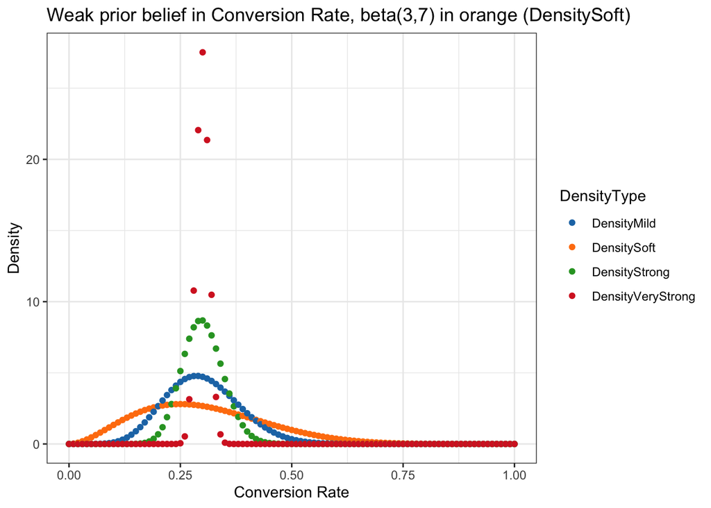

We’ve got new data O/N and have 36 clicks/114 non-clicks in Variant A, and 50 clicks / 100 non-clicks in Variant B. With this novel data we update our prior’s with the freshly arrive likelihood of 0.24 / 0.33 respectively.

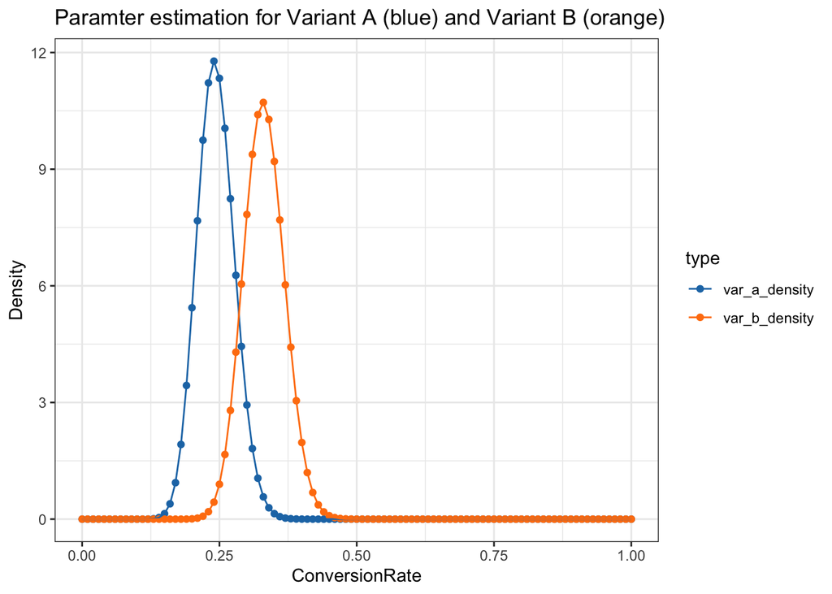

From looking at the estimated ConversionRate Density Plot, we suspect that Variant B is slightly more successful in generating clicks. But what if we were just unlucky, and the true conversion rate for Variant A is truely higher than the conversion rate of Variant B? So, how sure can we be that B is really the better variant?

**Let’s run a MonteCarlo (MC) simulation!**

What we do with a MC simulation, is that we randomly sample from the two distributions, where each sample is chosen based on its probability in the distribution. This means that samples from a high-probability region will appear more frequently. Looking at the above figure, we can see that it is more likely to sample a value greater than 0.2 in A than a value smaller than 0.2. At the same time, a random sample from distribution B is nearly certain to be higher than 0.2. What we do with MC simulation, is that we randomly sample from both distributions using “rbeta()” and compare how many times Var A wins/loses over Var b.

We will sample 100K samples from each distribution

Using rbeta() and the updated a/b to generate 100K samples each

Now we compare how often the conversion rate is higher in b vs. a:

```
## [1] 0.95877
```

This means, Variant B is in 96% of the worlds better (i.e has a higher conversion rate) than Variant A. Now in a Business Context, it’s usually necessary to express this certainty in numbers. Simply saying Variant B is better than A is not good enough. But to arrive at this numeric is quite easy: we can simply divide the b_samples by the a_samples.

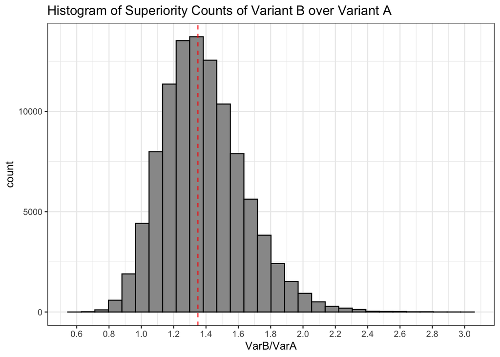

We can here estimate visually how many times VarB is better than VarA. Guesstimate: 1.35

Alternatively, we can use R’s empirical cumulative distribution function eCDF.

[figure not shown]